# Weather damage analysis (2002-2011)

Andrea

2022-09-17

## Synopsis

In this analysis we are briefly exploring the damages caused by harmful weather events between 2002 and 2011. When looking at population health, we can see that tornadoes are by far the most dangerous events, with a total of 14,700 people that have either been injured or killed by such event. Excessive heat is the second cause of death. However, when looking at the average number of people harmed by each event, we notice that actually hurricanes/typhoons are the most dangerous events, with an average of 15 people hurt with each time, followed by tsunamis (8). In comparison, the average number of people hurt by each tornado is 1, which occupies the 16th place in the chart. When looking at damage caused by such events on crops and properties, floods are the most expensive events, with an accumulated total damage of 136 billion USD between 2002 and 2011, followed by hurricanes (71 billion USD). Property damage is the biggest contributor in total damage: 133 billion USD (97% of total) for floods and 69 billion USD (96% of total) for hurricanes. For crops, the two most harmful events are droughts and floods.

## Data Processing

```r
library(data.table)
library(dplyr)
```

```r
library(ggplot2)

# 1. Download file if it's not in the working directory
if(!file.exists("./StormData.csv.bz2")){
   download.file("https://d396qusza40orc.cloudfront.net/repdata%2Fdata%2FStormData.csv.bz2",
              destfile = "./StormData.csv.bz2", method = "curl")
}

# 2. Read file
df <- fread("./StormData.csv.bz2")
head(df)
```

```
##    STATE__           BGN_DATE BGN_TIME TIME_ZONE COUNTY COUNTYNAME STATE
## 1:       1  4/18/1950 0:00:00     0130       CST     97     MOBILE    AL
## 2:       1  4/18/1950 0:00:00     0145       CST      3    BALDWIN    AL
## 3:       1  2/20/1951 0:00:00     1600       CST     57    FAYETTE    AL
## 4:       1   6/8/1951 0:00:00     0900       CST     89    MADISON    AL
## 5:       1 11/15/1951 0:00:00     1500       CST     43    CULLMAN    AL
## 6:       1 11/15/1951 0:00:00     2000       CST     77 LAUDERDALE    AL
##     EVTYPE BGN_RANGE BGN_AZI BGN_LOCATI END_DATE END_TIME COUNTY_END COUNTYENDN
## 1: TORNADO         0                                               0         NA
## 2: TORNADO         0                                               0         NA
## 3: TORNADO         0                                               0         NA
## 4: TORNADO         0                                               0         NA
## 5: TORNADO         0                                               0         NA
## 6: TORNADO         0                                               0         NA
##    END_RANGE END_AZI END_LOCATI LENGTH WIDTH F MAG FATALITIES INJURIES PROPDMG
```

[output cut: 20 more lines]

```r
str(df)
```

```
## Classes 'data.table' and 'data.frame':   902297 obs. of  37 variables:
##  $ STATE__   : num  1 1 1 1 1 1 1 1 1 1 ...
##  $ BGN_DATE  : chr  "4/18/1950 0:00:00" "4/18/1950 0:00:00" "2/20/1951 0:00:00" "6/8/1951 0:00:00" ...
##  $ BGN_TIME  : chr  "0130" "0145" "1600" "0900" ...
##  $ TIME_ZONE : chr  "CST" "CST" "CST" "CST" ...
##  $ COUNTY    : num  97 3 57 89 43 77 9 123 125 57 ...
##  $ COUNTYNAME: chr  "MOBILE" "BALDWIN" "FAYETTE" "MADISON" ...
##  $ STATE     : chr  "AL" "AL" "AL" "AL" ...
##  $ EVTYPE    : chr  "TORNADO" "TORNADO" "TORNADO" "TORNADO" ...
##  $ BGN_RANGE : num  0 0 0 0 0 0 0 0 0 0 ...
##  $ BGN_AZI   : chr  "" "" "" "" ...
##  $ BGN_LOCATI: chr  "" "" "" "" ...
##  $ END_DATE  : chr  "" "" "" "" ...
##  $ END_TIME  : chr  "" "" "" "" ...
##  $ COUNTY_END: num  0 0 0 0 0 0 0 0 0 0 ...
```

[output cut: 24 more lines]

```r
# 3. Data processing
df$BGN_DATE <- as.Date.character(df$BGN_DATE, "%m/%d/%Y")

main_df <- df[year(df$BGN_DATE) > (max(year(df$BGN_DATE)) - 10),
              c("BGN_DATE","COUNTYNAME","STATE","EVTYPE","FATALITIES",
                "INJURIES","PROPDMG","PROPDMGEXP","CROPDMG","CROPDMGEXP")]

main_df$crop_damage <- sapply(1:nrow(main_df),function(x){
  # DMGEXP: “K” thousands, “M” millions, “B” billions
  crop_dmg <- main_df$CROPDMG[x]
  crop_exp <- main_df$CROPDMGEXP[x]

  if(crop_exp == "K"){cxp = 1e+03}
  else if(crop_exp == "M"){cxp = 1e+06}
  else if(crop_exp == "B"){cxp = 1e+09}
  else{cxp = 1}

  tot_crop_dmg <- crop_dmg * cxp
  return(tot_crop_dmg)
})

main_df$prop_damage <- sapply(1:nrow(main_df),function(x){
  # DMGEXP: “K” thousands, “M” millions, “B” billions
  prop_dmg <- main_df$PROPDMG[x]
  prop_exp <- main_df$PROPDMGEXP[x]

  if(prop_exp == "K"){pxp = 1e+03}
  else if(prop_exp == "M"){pxp = 1e+06}
  else if(prop_exp == "B"){pxp = 1e+09}
  else{pxp = 1}

  tot_prop_dmg <- prop_dmg * pxp
  return(tot_prop_dmg)
})

main_df$total_damage <- main_df$crop_damage + main_df$prop_damage

main_df$tot_harmed_people <- main_df$FATALITIES + main_df$INJURIES

# 4. Remove original df to free up some memory
rm(df)
```

# Which types of events are most harmful to population health?

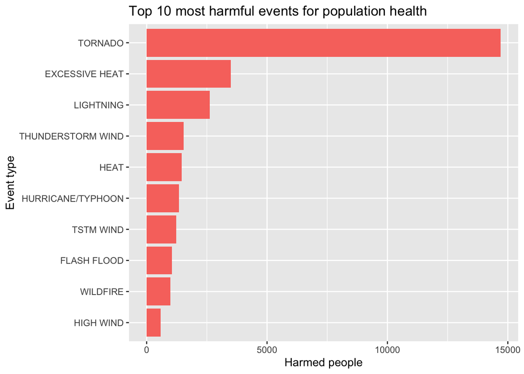

```r
q1 <- main_df %>% group_by(EVTYPE) %>% summarise(tot_ppl = sum(tot_harmed_people),
                                                 avg_ppl = mean(tot_harmed_people),
                                                 injured = sum(INJURIES),
                                                 fatal = sum(FATALITIES))

head(q1[order(q1$tot_ppl, decreasing = T),],10) %>%
  ggplot(aes(y = reorder(EVTYPE,tot_ppl), x=tot_ppl, fill = "tot_ppl")) +
  geom_bar(stat = "identity") +
  xlab("Harmed people") +
  ylab("Event type") +
  ggtitle("Top 10 most harmful events for population health") +
  theme(legend.position = "none")
```

```r
head(q1[order(q1$avg_ppl, decreasing = T),c(1,3)],16)
```

```
## # A tibble: 16 × 2
##    EVTYPE             avg_ppl
##    <chr>                <dbl>
##  1 HURRICANE/TYPHOON   15.2
##  2 TSUNAMI              8.1
##  3 ROUGH SEAS           4
##  4 EXCESSIVE HEAT       3.87
##  5 RIP CURRENTS         2.07
##  6 HEAT                 2.05
##  7 COLD WEATHER         2
##  8 FOG                  2
##  9 HIGH SEAS            1.5
## 10 WINTER WEATHER MIX   1.5
## 11 HEAVY SURF           1.33
## 12 RIP CURRENT          1.27
## 13 DROWNING             1
## 14 HAZARDOUS SURF       1
## 15 ICE ON ROAD          1
## 16 TORNADO              0.969
```

# Which types of events have the greatest economic consequences?

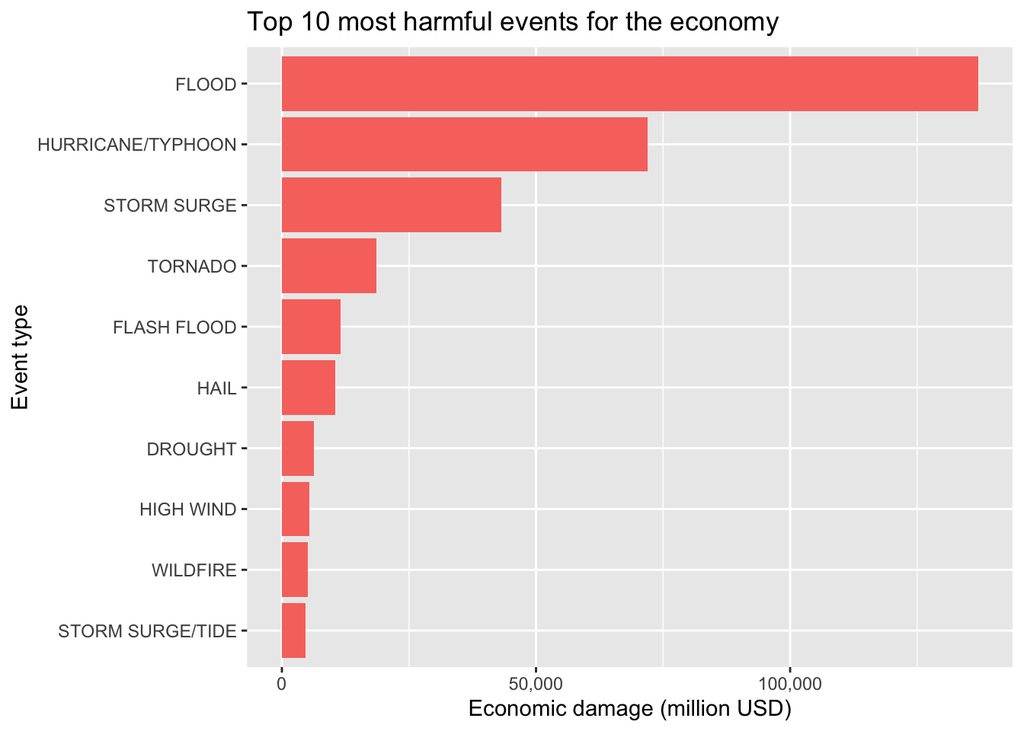

```r
q2 <- main_df %>% group_by(EVTYPE) %>% summarise(tot_dmg = as.integer(sum(total_damage)/1000000),
                                                 avg_dmg = mean(total_damage),
                                                 crop = sum(crop_damage)/1000000,
                                                 prop = sum(prop_damage)/1000000)

head(q2[order(q2$tot_dmg, decreasing = T),],10) %>%
  ggplot(aes(y = reorder(EVTYPE,tot_dmg), x=tot_dmg, fill = "tot_dmg")) +
  geom_bar(stat = "identity") +
  xlab("Economic damage (million USD)") +
  ylab("Event type") +
  ggtitle("Top 10 most harmful events for the economy") +
  theme(legend.position = "none") +
  scale_x_continuous(labels = scales::comma)
```

```r
print("Total damage:")
```

```
## [1] "Total damage:"
```

```r
head(q2[order(q2$tot_dmg, decreasing = T),],3)
```

```
## # A tibble: 3 × 5
##   EVTYPE            tot_dmg    avg_dmg  crop    prop
##   <chr>               <int>      <dbl> <dbl>   <dbl>
## 1 FLOOD              136979   7580076. 3592. 133388.
## 2 HURRICANE/TYPHOON   71913 817201282. 2608.  69306.
## 3 STORM SURGE         43168 419109854.    0   43168.
```

```r
print("Crop damage:")
```

```
## [1] "Crop damage:"
```

```r
head(q2[order(q2$crop, decreasing = T),],3)
```

```
## # A tibble: 3 × 5
##   EVTYPE            tot_dmg    avg_dmg  crop    prop
##   <chr>               <int>      <dbl> <dbl>   <dbl>
## 1 DROUGHT              6269   3398148. 5424.    846.
## 2 FLOOD              136979   7580076. 3592. 133388.
## 3 HURRICANE/TYPHOON   71913 817201282. 2608.  69306.
```